# student-engagement-analysis

1. Import Libraries
2. Load Dataset
3. Data Understanding
4. Data Cleaning
5. Exploratory Data Analysis (EDA)
6. Feature Engineering
7. Model Building
8. Model Evaluation
9. Conclusion / Business Insights

```python
# Importing Library
import pandas as pd
import numpy as np

import matplotlib.pyplot as plt
import seaborn as sns

from sklearn.model_selection import train_test_split
from sklearn.linear_model import LogisticRegression
from sklearn.metrics import classification_report, confusion_matrix
```

```python
df = pd.read_excel(r"C:\Users\DELL\Desktop\learning-engagement-completion-analysis.xlsx",nrows=500000)
```

```python
df.head(5)
```

|  | batch_id | instructor_id | course_id | completion_rate | avg_score_improvement | avg_quiz_score | dropout_rate | avg_watch_time | assignment_submission_rate | forum_activity_rate | avg_feedback_score | feedback_response_rate |
| --- | --- | --- | --- | --- | --- | --- | --- | --- | --- | --- | --- | --- |
| 0 | B_1861 | I_044 | C_01 | 0.300000 | 14.225955 | 73.546528 | 0.647423 | 0.774572 | 0.790918 | 0.108414 | 3.766211 | 0.533193 |
| 1 | B_0354 | I_119 | C_06 | 0.657220 | 22.871110 | 77.312331 | 0.425098 | 0.494936 | 0.998566 | 0.280550 | 5.000000 | 0.734087 |
| 2 | B_1334 | I_050 | C_03 | 0.300000 | 16.087517 | 79.563687 | 0.700000 | 0.977901 | 0.807298 | 0.207013 | 3.517386 | 0.681433 |
| 3 | B_0906 | I_024 | C_21 | 0.639507 | 24.260687 | 99.295316 | 0.334657 | 0.846515 | 0.544555 | 0.306395 | 4.207578 | 1.000000 |
| 4 | B_1290 | I_001 | C_08 | 0.527302 | 31.081556 | 99.393425 | 0.521099 | 0.917450 | 0.865885 | 0.252289 | 4.426230 | 0.696710 |

```python
df.info()
```

```
<class 'pandas.core.frame.DataFrame'>
RangeIndex: 2000 entries, 0 to 1999
Data columns (total 12 columns):
 #   Column                      Non-Null Count  Dtype
---  ------                      --------------  -----
 0   batch_id                    2000 non-null   object
 1   instructor_id               2000 non-null   object
 2   course_id                   2000 non-null   object
 3   completion_rate             2000 non-null   float64
 4   avg_score_improvement       2000 non-null   float64
 5   avg_quiz_score              2000 non-null   float64
 6   dropout_rate                2000 non-null   float64
 7   avg_watch_time              2000 non-null   float64
 8   assignment_submission_rate  2000 non-null   float64
 9   forum_activity_rate         2000 non-null   float64
 10  avg_feedback_score          2000 non-null   float64
 11  feedback_response_rate      2000 non-null   float64
dtypes: float64(9), object(3)
memory usage: 187.6+ KB
```

```python
df.shape
```

```
(2000, 12)
```

```python
df.columns
```

```
Index(['batch_id', 'instructor_id', 'course_id', 'completion_rate',
       'avg_score_improvement', 'avg_quiz_score', 'dropout_rate',
       'avg_watch_time', 'assignment_submission_rate', 'forum_activity_rate',
       'avg_feedback_score', 'feedback_response_rate'],
      dtype='object')
```

## The dataset contains instructor performance metrics across different courses and batches. The features represent engagement metrics, learning outcomes, and feedback indicators.

```python
df.isnull().sum()
```

```
batch_id                      0
instructor_id                 0
course_id                     0
completion_rate               0
avg_score_improvement         0
avg_quiz_score                0
dropout_rate                  0
avg_watch_time                0
assignment_submission_rate    0
forum_activity_rate           0
avg_feedback_score            0
feedback_response_rate        0
dtype: int64
```

## In this data set there is no missing values

## So, No imputation is required

```python
df.duplicated().sum()
```

```
np.int64(0)
```

```python
df.describe()
```

|  | completion_rate | avg_score_improvement | avg_quiz_score | dropout_rate | avg_watch_time | assignment_submission_rate | forum_activity_rate | avg_feedback_score | feedback_response_rate |
| --- | --- | --- | --- | --- | --- | --- | --- | --- | --- |
| count | 2000.000000 | 2000.000000 | 2000.000000 | 2000.000000 | 2000.000000 | 2000.000000 | 2000.000000 | 2000.000000 | 2000.000000 |
| mean | 0.602808 | 27.035844 | 77.956126 | 0.394883 | 0.776515 | 0.753188 | 0.250300 | 4.207134 | 0.736519 |
| std | 0.159667 | 5.716641 | 10.695618 | 0.162747 | 0.145231 | 0.148058 | 0.100640 | 0.419209 | 0.149412 |
| min | 0.300000 | 6.159240 | 40.386725 | 0.020000 | 0.287440 | 0.251111 | 0.000000 | 2.639915 | 0.259935 |
| 25% | 0.489260 | 23.124673 | 70.897590 | 0.280035 | 0.675076 | 0.652110 | 0.179845 | 3.918986 | 0.633293 |
| 50% | 0.603091 | 26.938629 | 78.020567 | 0.394820 | 0.780330 | 0.756380 | 0.249771 | 4.205989 | 0.737213 |
| 75% | 0.712797 | 30.885600 | 85.444286 | 0.511432 | 0.894242 | 0.856458 | 0.319204 | 4.503437 | 0.845876 |
| max | 0.980000 | 40.000000 | 100.000000 | 0.700000 | 1.000000 | 1.000000 | 0.641111 | 5.000000 | 1.000000 |

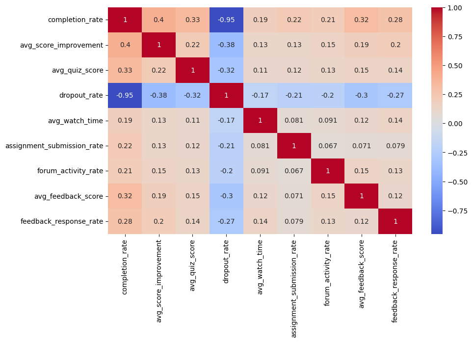

```python
corr = df.corr(numeric_only= True)

plt.figure(figsize = (10,6))
sns.heatmap(corr,annot=True, cmap= "coolwarm")

plt.show()
```

# Engagement VS Completion Analysis

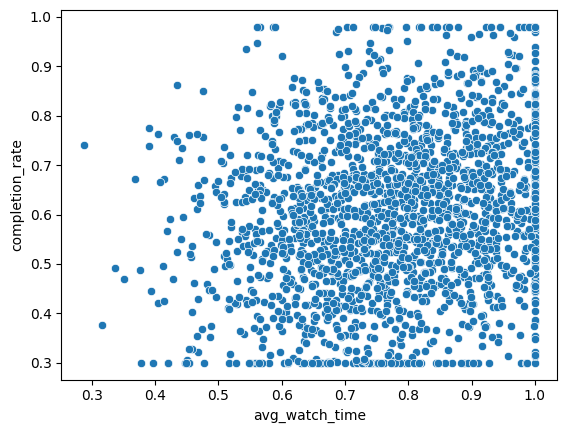

```python
sns.scatterplot(x = df["avg_watch_time"],y = df["completion_rate"])
plt.show()
```

# Dropout_Analysis

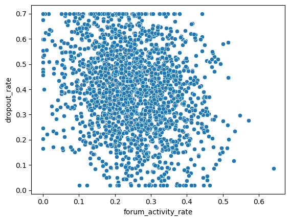

```python
sns.scatterplot(x = df["forum_activity_rate"],y = df["dropout_rate"])
plt.show()
```

```python
X = df.drop(["completion_rate","batch_id","instructor_id","course_id"],axis = 1)
y = df["completion_rate"]
```

```python
X_train, X_test, y_train, y_test = train_test_split(
    X,
    y,
    test_size=0.2,
    random_state=42
)
```

```python
from sklearn.ensemble import RandomForestRegressor

model = RandomForestRegressor()

model.fit(X_train, y_train)
```

```
RandomForestRegressor()
```

```python
pred = model.predict(X_test)
```

```python
from sklearn.metrics import mean_squared_error, r2_score

print("MSE:", mean_squared_error(y_test, pred))

print("R2 Score:", r2_score(y_test, pred))
```

```
MSE: 0.0023446383086343854
R2 Score: 0.9149148631463447
```

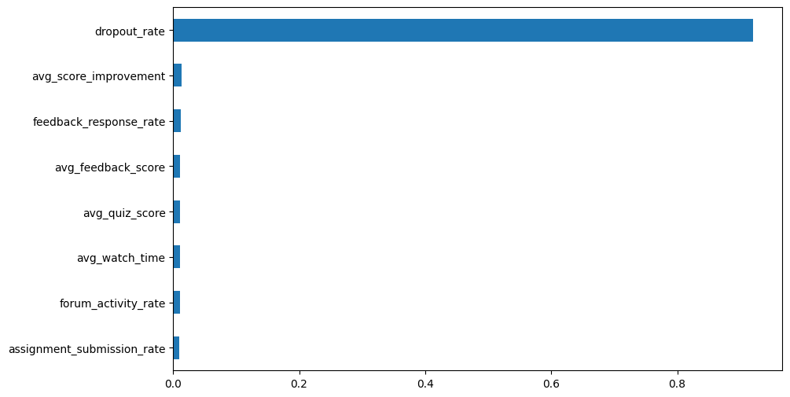

```python
importance = model.feature_importances_

import pandas as pd

features = pd.Series(importance, index=X.columns)

features.sort_values().plot(kind="barh", figsize=(10,6))
```

## Ques6. Do these factors make sense? If yes, How? If not, How not?

### Yes. Higher engagement metrics such as watch time, assignment submissions, and forum participation logically contribute to better course completion rates and learning outcomes.

## Ques7. What kind of prevention should be adopted while company update its infrastructure?

### Platform should:

encourage forum participation

increase assignment engagement

provide faster instructor feedback

track low engagement learners

## Ques8. Assuming these actions have been implemented, how would you determine if they work?

### Measures:-

increase in completion rate

reduction in dropout rate

higher average quiz scores

improved learner engagement

## Future Improvements

Gradient Boosting Models

XGBoost

Feature Engineering

Student segmentation